# presentation-live

## Liší se průměrná hmotnost těla mezi druhy tučňáků?

BIOSTATISTIKA

L06

Když prediktor není číslo: od dvou průměrů k analýze rozptylu

cuni-natur-biostatistics.github.io/materialy.html

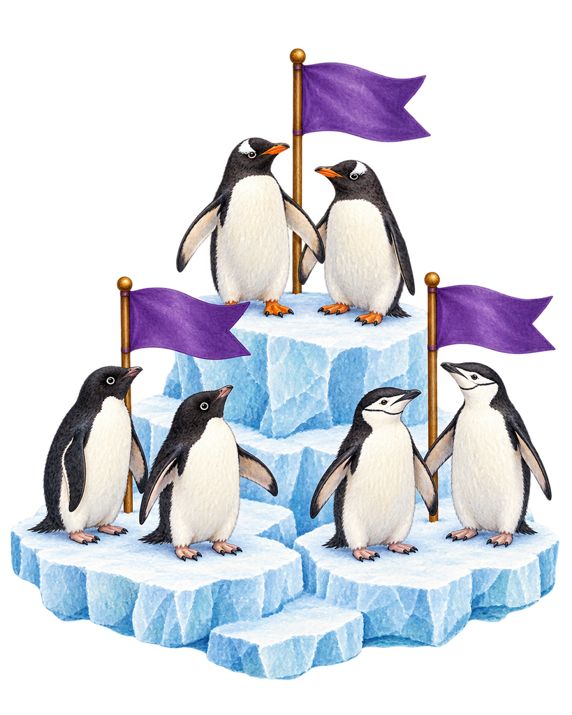

Ilustrace vytvořená pomocí AI. Anatomická reference: Allison Horst, CC0.

## Liší se průměrná hmotnost mezi druhy tučňáků?

Biologická otázka

Je rozdíl mezi druhy větší, než bychom čekali od variability jednotlivých tučňáků?

Ilustrace: Allison Horst · Data: Palmer Station LTER / palmerpenguins

## Co si pamatujete z minulé lekce?

Odpovězte samostatně na tři krátké otázky. Společné odpovědi projdeme po hlasování.

## Spočítejte t-statistiku sklonu a určete residuální stupně volnosti. Model stojí na průměrech lokalit.

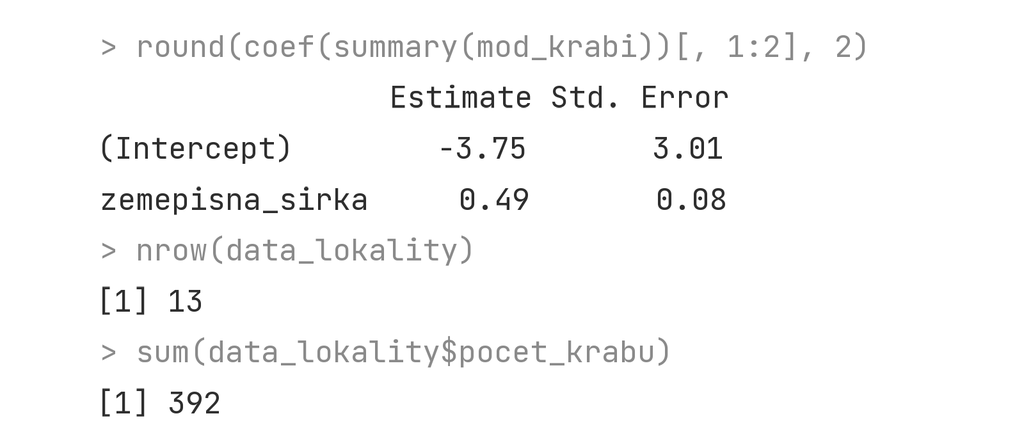

- t ≈ 6; df = 11
- t ≈ 6; df = 390
- t ≈ 6; df = 13
- t ≈ 0,16; df = 390

Správná odpověď: t ≈ 6; df = 11

t = odhad / SE = 0,49 / 0,08 ≈ 6. Jednotkou pozorování je lokalita, ne krab: df = 13 lokalit − 2 koeficienty = 11.

## Test sklonu dal p = 0,00007. Která věta je správná?

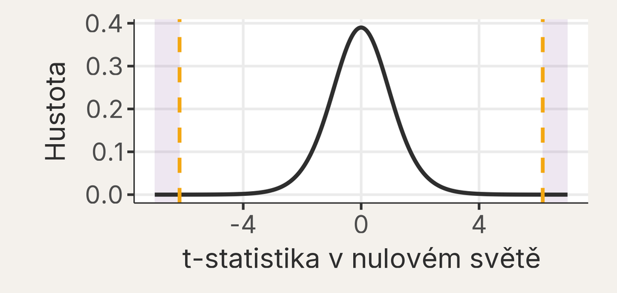

- Pravděpodobnost, že sklon vznikl jen náhodou, je pouhých 0,007 %.
- Za platnosti H₀ by odhad alespoň takto vzdálený od nuly vycházel zřídka.
- S pravděpodobností 99,993 % se krunýř směrem k severu skutečně zvětšuje.
- Kdybychom studii zopakovali, vyšla by významná s pravděpodobností 99,993 %.

Správná odpověď: Za platnosti H₀ by odhad alespoň takto vzdálený od nuly vycházel zřídka.

P-hodnota se počítá za předpokladu, že platí H₀ a model. Není pravděpodobností hypotézy, „náhody“ ani opakování výsledku.

## Jiná studie změřila kraby jen na 4 lokalitách. Který závěr je nejlepší?

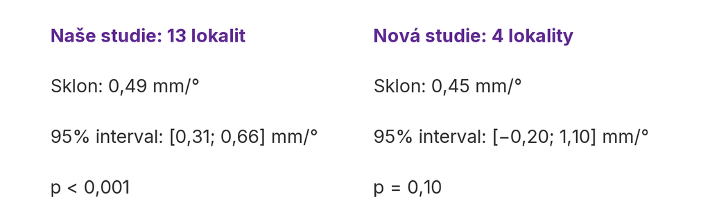

- Nová studie ukazuje, že zeměpisná šířka s šířkou krunýře nesouvisí.
- Obě studie si odporují, protože jedna je významná a druhá ne.
- Nová studie nezamítla H₀, takže se dopustila chyby I. typu.
- Data jsou slučitelná s nulou i s naším sklonem 0,49 mm/°.

Správná odpověď: Data jsou slučitelná s nulou i s naším sklonem 0,49 mm/°.

Interval obsahuje nulu i náš sklon 0,49 mm/°. Nevýznamnost nedokazuje nulový efekt; malá studie mohla efekt přehlédnout (chyba II. typu).

## Výsledky učení

Po absolvování této přednášky budete schopni:

- fitovat `lm(y ~ skupina)` pro dvě i více skupin a přečíst jeho koeficienty;
- interpretovat intercept jako průměr referenční skupiny a další koeficienty jako rozdíly vůči ní;
- vysvětlit dvouvýběrový t-test a analýzu rozptylu (ANOVA) jako otázky položené lineárnímu modelu;
- rozlišit celkový F-test od post-hoc porovnání dvojic a rozhodnout, kdy párová porovnání dávají smysl;
- napsat závěr v biologicky smysluplných jednotkách: rozdíl, nejistota, test a omezení studie.

## Stejná logika, jiný typ prediktoru

Efekt, nejistotu a důkaz čteme stejně jako u přímky. Mění se jen prediktor: místo čísla je to **skupina**.

## Jak těžcí jsou tučňáci?

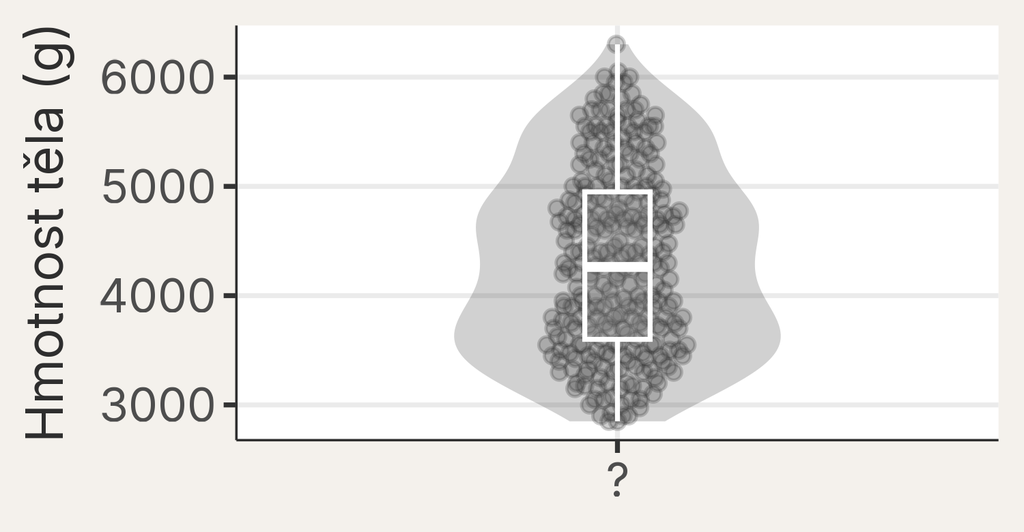

Co by mohlo vytvářet tak široký rozsah hodnot?

## Barva odkryje skupiny

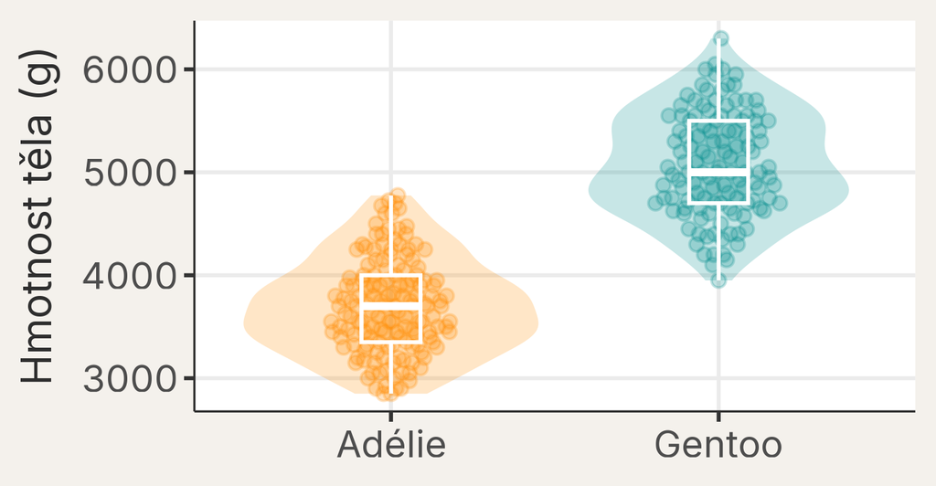

Vidíme rozdíly mezi skupinami **i** variabilitu uvnitř skupin.

## Co by předpovídala nulová hypotéza?

Hlasování

Kdyby druh s hmotností nesouvisel, jaký vzorec bychom čekali?

A

Stejný průměr, žádná variabilita.

B

Stejný průměr, variabilita zůstává.

C

Jiný průměr pro každý druh.

## Průměr neříká celý příběh

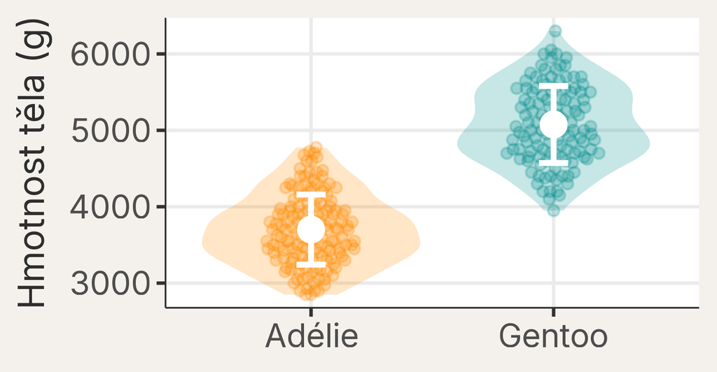

Bílý bod: průměr druhu · bílá úsečka: průměr ± 1 SD

Rozdíl průměrů hodnotíme vůči variabilitě jednotlivých pozorování.

# Rozdíl mezi dvěma skupinami

## Dvě vzdálenosti na jedné kře

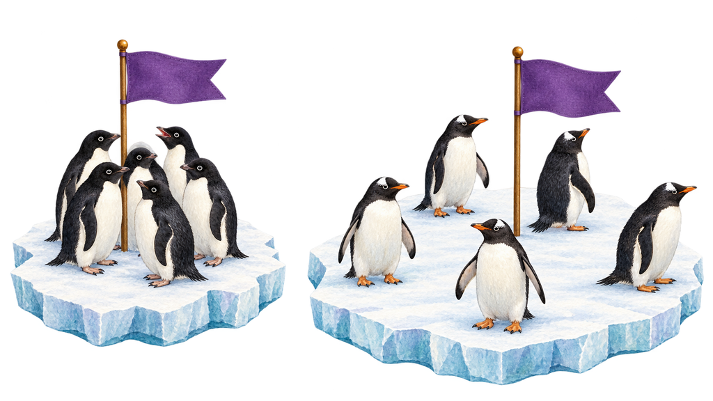

Ilustrace vytvořená pomocí AI.

**uvnitř skupin**: jak daleko jsou jedinci od vlastního průměru

**mezi skupinami**: jak daleko jsou skupinové průměry od sebe

## Stejný rozdíl průměrů, jiný vnitřní rozptyl

Odhad bez počítání

Dvě vymyšlené skupiny A a B. Rozdíl průměrů je vždy **1 000 g**. Ve kterém panelu máme největší šanci zamítnout nulovou hypotézu?

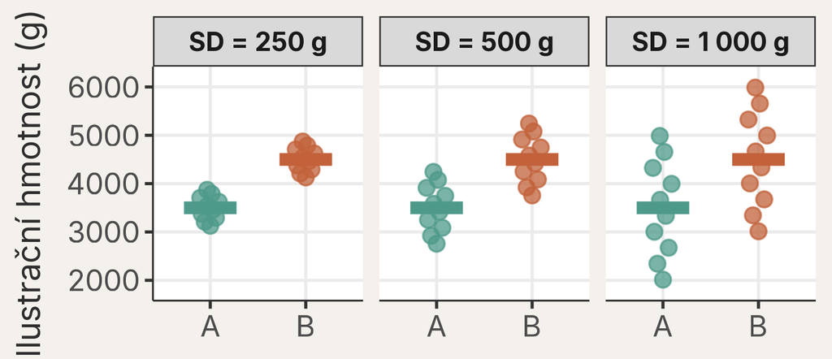

# Lineární model

## Stejná věc, různé názvy

Ve statistice mívá tatáž věc několik názvů a symbolů. Tady se změní jen zápis, ne rovnice.

$$\text{odhadnutá hodnota}
=
\text{intercept}
+
\text{sklon} \times \text{prediktor}$$

Do minulé lekce

$$\hat{y}_i = a + b\,x_i$$

Od této lekce

$$\hat{y}_i = \hat{\beta}_0 + \hat{\beta}_1 x_i$$

$\hat{\beta}_0$ je dřívější $a$, $\hat{\beta}_1$ je dřívější $b$. Stříška označuje odhad z našich dat.

## Kolik čísel popíše dva průměry?

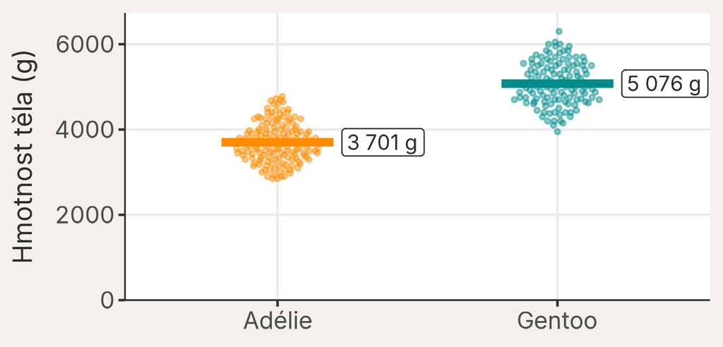

Kolik čísel potřebujeme, abychom znali oba průměry? Musí to být právě tyto dva průměry?

## Stačí průměr Adélie a rozdíl

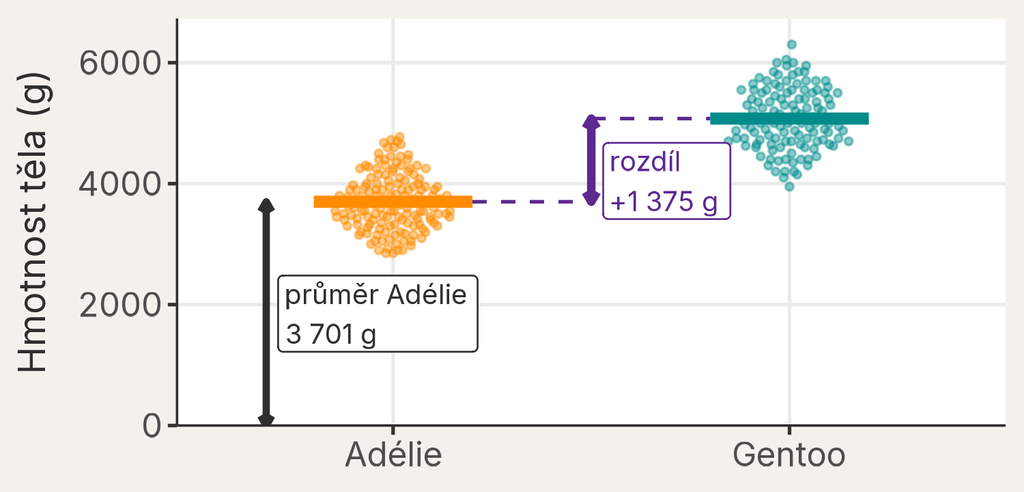

Průměr Gentoo dostaneme z průměru Adélie a rozdílu: 3 701 g + 1 375 g = 5 076 g.

## Jak dostaneme druh do rovnice?

Diskuze ve dvojici — 90 sekund

Rovnice přímky počítá s čísly, ale druh je název. Jak bychom mohli druh zapsat číslem, aby rovnice buď nechala průměr Adélie, nebo k němu přičetla rozdíl?

| Druh | „je Gentoo?“ |
| --- | --- |
| Adélie | 0 |
| Gentoo | 1 |

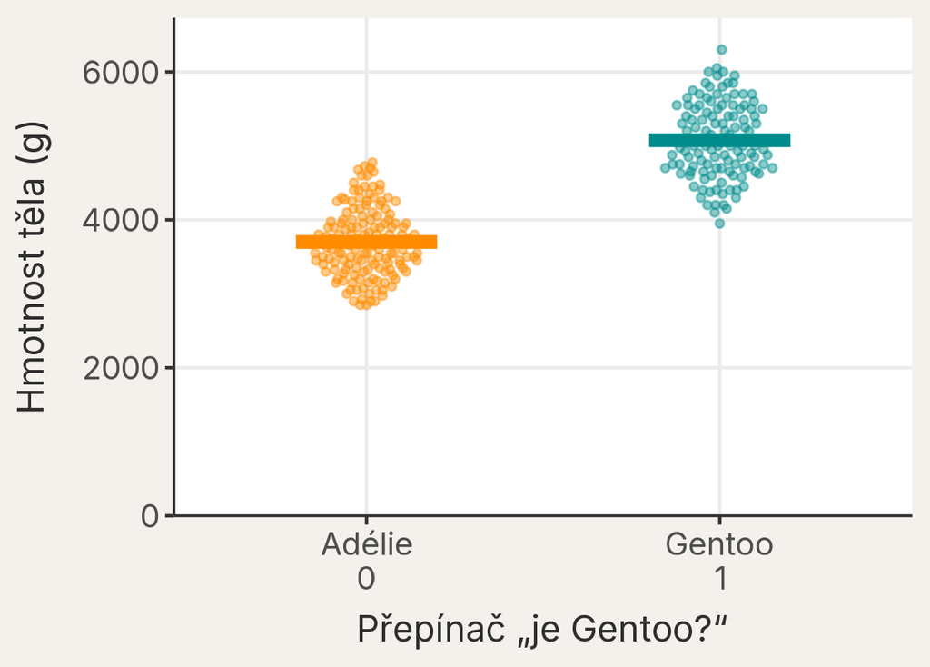

Číslo 0 nebo 1 rozhodne, zda se rozdíl přičte. Říkáme mu **přepínač**.

## Když je $x$ jen 0, nebo 1

Adélie: $x = 0$

$\hat{y} = \hat{\beta}_0$

Gentoo: $x = 1$

$\hat{y} = \hat{\beta}_0 + \hat{\beta}_1$

Přímka spojí oba průměry. Při přechodu z Adélie (0) ke Gentoo (1) stoupne o rozdíl, takže **sklon je rozdíl průměrů**.

Mezi 0 a 1 žádný tučňák neleží a druhy nemají pořadí.

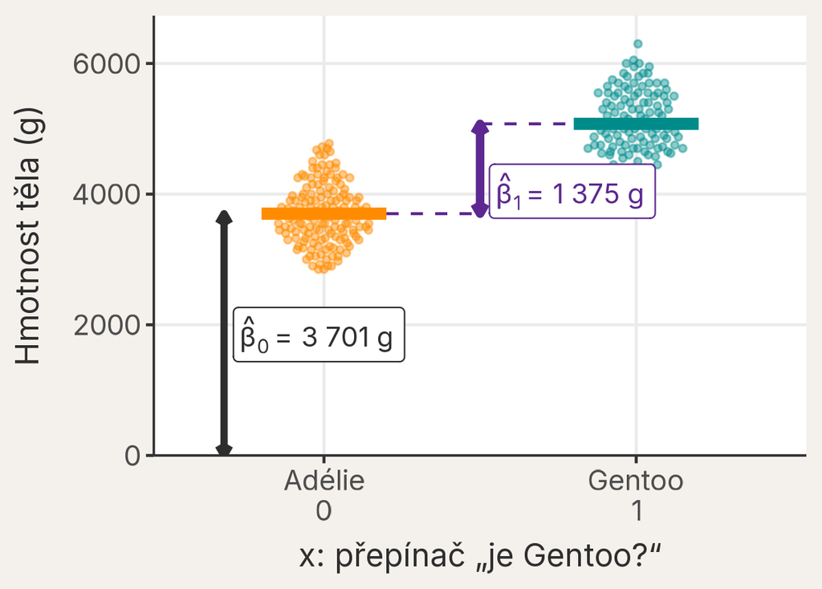

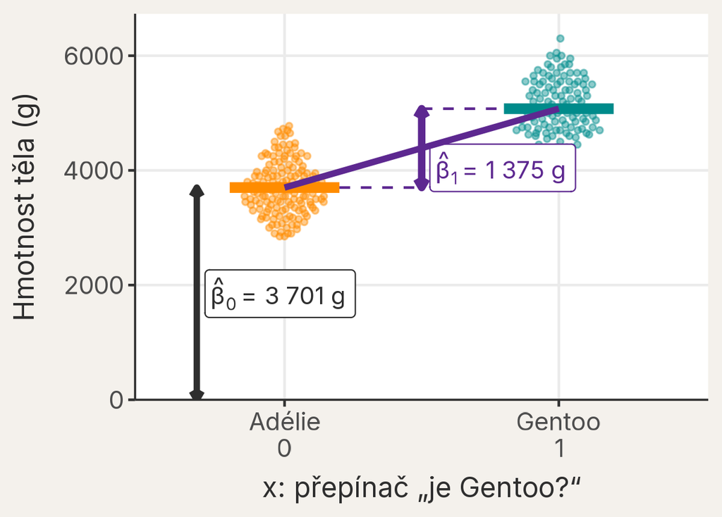

## Nula nechá průměr Adélie, jednička přičte rozdíl

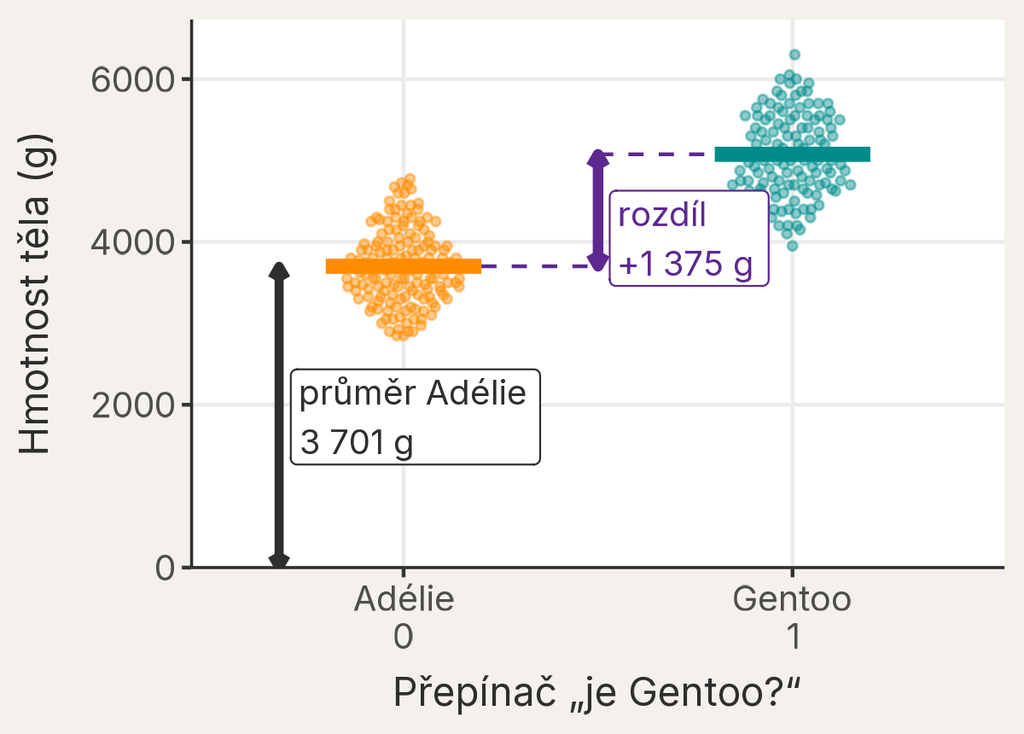

$$\begin{aligned}
\text{odhadnutá hmotnost}
={}& \text{průměr Adélie} \\
&+ \text{přepínač} \times \text{rozdíl}
\end{aligned}$$

Adélie: přepínač 0

$$3\,701
+ 0 \times 1\,375
= 3\,701\ \mathrm{g}$$

Gentoo: přepínač 1

$$3\,701
+ 1 \times 1\,375
= 5\,076\ \mathrm{g}$$

Nula rozdíl vypne. Jednička ho zapne.

## Jedna rovnice popíše oba druhy

$$\hat{y}_i = \hat{\beta}_0 + \hat{\beta}_1 x_i$$

| Symbol | Význam v našich datech |
| --- | --- |
| $\hat{y}_i$ | odhadnutá hmotnost tučňáka $i$ |
| $\hat{\beta}_0$ | průměr Adélie |
| $\hat{\beta}_1$ | rozdíl Gentoo minus Adélie |
| $x_i$ | přepínač: 0 pro Adélie, 1 pro Gentoo |

**Stejná rovnice jako pro numerický prediktor, jen interpretace koeficientů se liší.**

## Referenční druh

[figure not shown]

Ilustrace vytvořená pomocí AI.

Model zapisuje jednu skupinu (druh) přímo a ostatní jako rozdíly vůči ní.

## Která skupina je referenční?

```r
# Ponecháme dva druhy a odstraníme nevyužitou úroveň faktoru
data_penguins_two <-
  data_penguins[data_penguins$druh %in% c("Adelie", "Gentoo"), ]
data_penguins_two$druh <- droplevels(data_penguins_two$druh)

# První úroveň faktoru je referenční skupina
levels(x = data_penguins_two$druh)
```

```
[1] "Adelie" "Gentoo"
```

První úroveň

`Adelie` je referenční skupina.

Výsledek

R vytvoří koeficient `druhGentoo`.

Pořadí úrovní faktoru je součást interpretace modelu.

## Stejná funkce `lm()`, nový prediktor

```r
# Stejná formule jako u přímky, jen prediktorem je druh
mod_dva <-
  lm(
    formula = hmotnost_tela_g ~ druh,
    data = data_penguins_two
  )

# Intercept a rozdíl Gentoo minus Adélie
coef(object = mod_dva)
```

```
(Intercept)  druhGentoo
   3700.662    1375.354
```

Které číslo ve výstupu je průměr Adélie a které rozdíl mezi druhy?

## Dva koeficienty

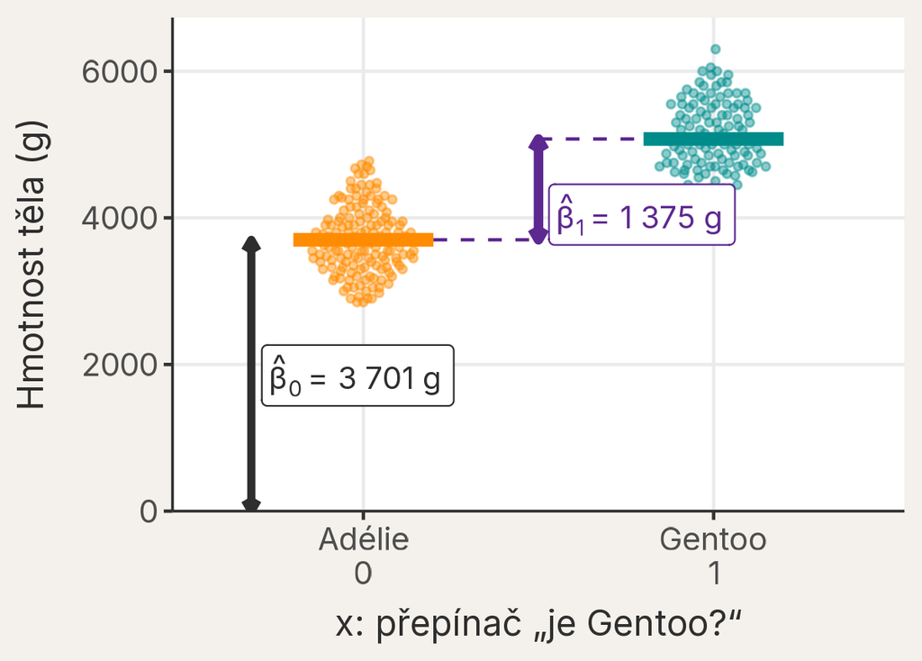

`(Intercept)`: černá šipka

3 701 g

Průměrná hmotnost druhu **Adélie**.

`druhGentoo`: fialová šipka

+1 375 g

Rozdíl **Gentoo − Adélie**.

Gentoo: 5 076 g = průměr referenční skupiny + rozdíl.

## Referenční skupina není „nejdůležitější“ skupina

Hlasování

Změníme referenční skupinu z Adélie na Gentoo. Co se musí změnit?

A

Odhadnuté hodnoty, tedy průměry obou druhů v modelu.

B

Hodnota interceptu a název i znaménko rozdílu.

C

Residua jednotlivých tučňáků v obou skupinách.

Referenční skupina mění souřadný systém popisu — ne data ani odhadnuté hodnoty modelu.

## V pokusu s kontrolou je přirozenou referenční skupinou kontrola

| Skupina | Koeficient | Význam |
| --- | --- | --- |
| **kontrola** | $\hat{\beta}_0$ | průměr kontroly |
| **lék A** | $\hat{\beta}_1$ | A − kontrola |
| **lék B** | $\hat{\beta}_2$ | B − kontrola |

**Je-li kontrola referenční skupinou, každý koeficient odpovídá přirozené otázce „oproti kontrole“.**

## Referenční skupina nevytváří kontrolu

Pozor na interpretaci

Příkaz `relevel()` pouze změní, kterou skupinu model používá jako výchozí.

Nevytváří randomizaci, kontrolní podmínky ani kauzální důkaz.

```r
data_pokus <-
  data.frame(
    skupina = factor(c("kontrola", "lék A", "lék B"))
  )

data_pokus$skupina <-
  relevel(
    x = data_pokus$skupina,
    ref = "kontrola"
  )
```

Kontrolní skupinu vytváří design studie. Referenční skupina pouze zpřehlední otázku.

## Každý tučňák dostane průměr svého druhu

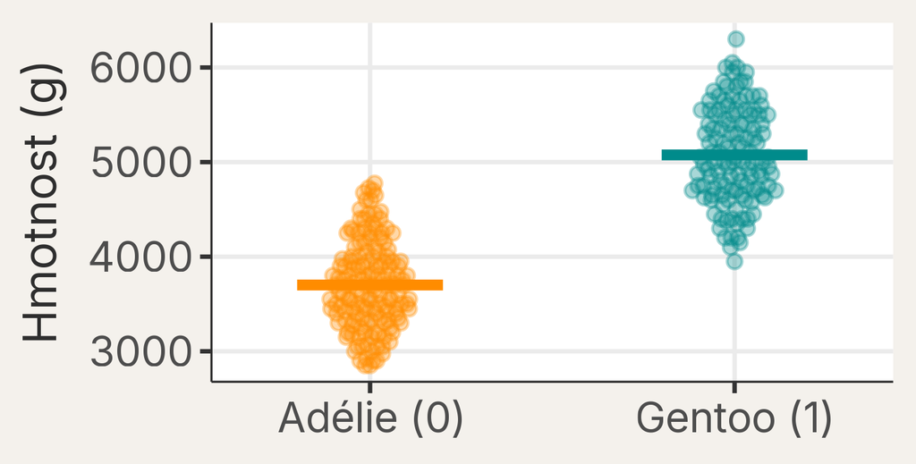

Odhadnutá hodnota každého tučňáka je průměr jeho druhu.

## Residuum je stále vzdálenost od odhadnuté hodnoty

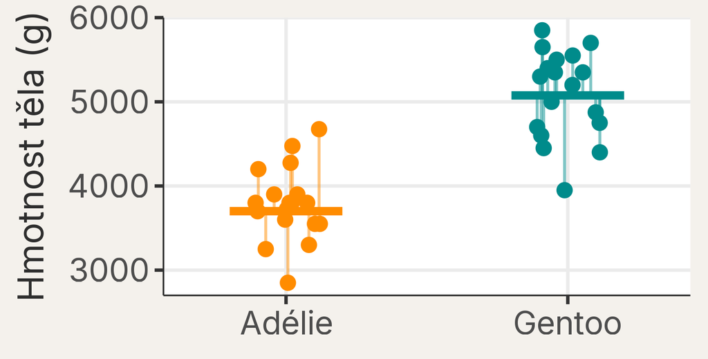

Pro přehlednost 18 náhodně vybraných tučňáků z každého druhu.

Jiný tvar prediktoru, stejná definice residua.

30 sekund se sousedem

Ukažte tučňáka s kladným residuem. Co residuum říká o jeho hmotnosti vzhledem k průměru jeho druhu?

## Jak přesně jsme odhadli rozdíl?

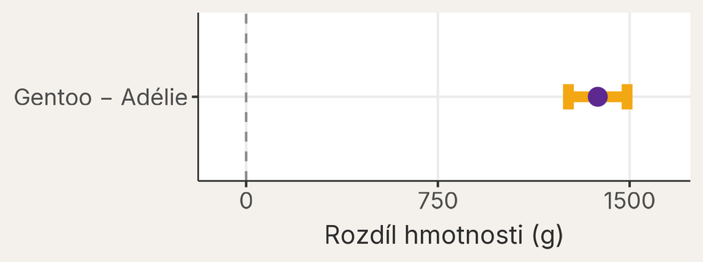

Odhad: **+1 375 g**

95% CI: 1 261 až 1 490 g

## Je rozdíl slučitelný s nulou?

$H_0$: průměr Gentoo − průměr Adélie = 0 g ($\beta_1 = 0$)

$H_A$: průměr Gentoo − průměr Adélie ≠ 0 g ($\beta_1 \neq 0$)

$t$-statistika: vzdálenost od nuly ve standardních chybách

$$t = \frac{\text{odhad rozdílu} - 0}{\text{standardní chyba rozdílu}}
= \frac{1\,375 - 0}{\text{58,2}}
= \text{23,61}$$

Pro dvě skupiny dává tento model stejnou testovou otázku jako klasický dvouvýběrový t-test se společným rozptylem.

## Kde leží naše $t$ v nulovém rozdělení?

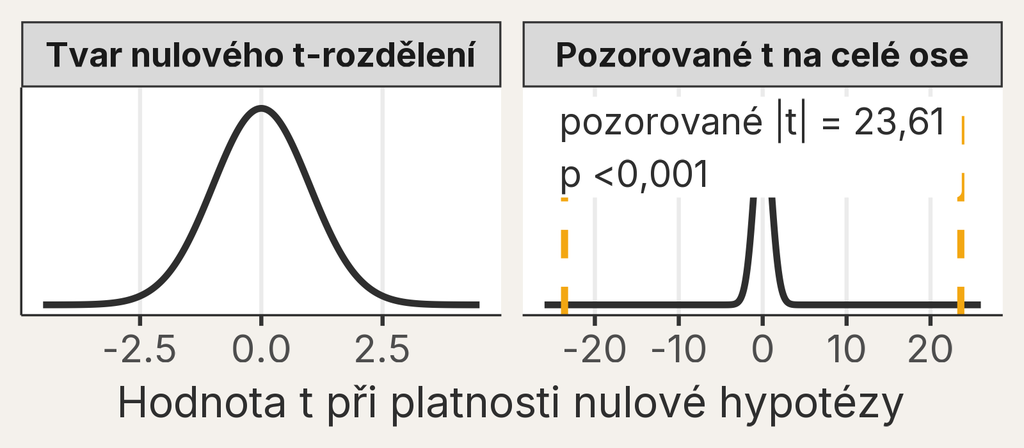

p-hodnota <0,001 je plocha v obou chvostech ještě dál od nuly než pozorované $t$.

## Rozdíl, nejistota a test v jedné tabulce

| Srovnání | Odhad (g) | Std. chyba (g) | t | p |
| --- | --- | --- | --- | --- |
| Gentoo − Adélie | 1 375 | 58,2 | 23,61 | <0,001 |

Odhad rozdílu čteme spolu s jeho nejistotou a důkazem proti nulové hypotéze.

## Co můžeme říci biologicky?

Řekněte sousedovi dvěma větami

Jedna věta o gramech, jedna o tom, co data říkají o nulové hypotéze.

Rozdíl v gramech

V tomto souboru jsou tučňáci Gentoo v průměru o přibližně **1 375 g těžší** než tučňáci Adélie (95% interval 1 261 až 1 490 g).

Data a nulová hypotéza

Kdyby se průměrná hmotnost obou druhů v populaci nelišila, rozdíl aspoň takhle velký by byl velmi nepravděpodobný (t = 23,61, p < 0,001). Data jsou proto s nulovou hypotézou **velmi obtížně slučitelná**.

Rozsah závěru

Jde o asociaci v pozorovaných datech, ne o důkaz, že rozdíl způsobuje sám druh.

# Více skupin

## Co se stane, když přidáme třetí druh?

Tip

Kolik koeficientů potřebujeme pro tři skupinové průměry?

A

Jeden

B

Dva

C

Tři

tři průměry = jeden referenční (intercept) + dva rozdíly

## Tři druhy, tři průměry

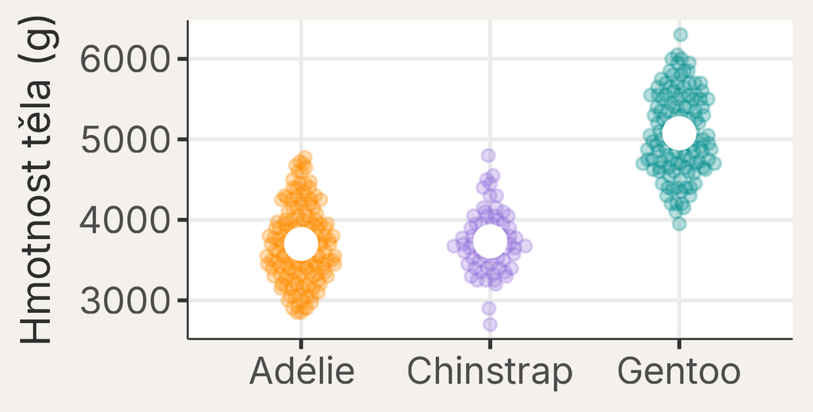

Adélie a Chinstrap mají podobné průměry; Gentoo je zřetelně výše.

## Tři průměry potřebují dva přepínače

| Druh | Referenční průměr Adélie | Je Chinstrap? | Je Gentoo? |
| --- | --- | --- | --- |
| Adélie | 1 | 0 | 0 |
| Chinstrap | 1 | 1 | 0 |
| Gentoo | 1 | 0 | 1 |

Každý řádek říká, které rozdíly se mají přičíst k průměru Adélie.

## Tři průměry potřebují dva přepínače

$$\begin{aligned}
\text{odhadnutá hmotnost}
={}& \text{průměr Adélie} \\
&+ \text{přepínač Chinstrap}
\times \text{rozdíl Chinstrap minus Adélie} \\
&+ \text{přepínač Gentoo}
\times \text{rozdíl Gentoo minus Adélie}
\end{aligned}$$

## Tři koeficienty z jednoho modelu

```r
# Stejná formule jako u dvou druhů, jen na všech třech druzích
mod_tri <-
  lm(
    formula = hmotnost_tela_g ~ druh,
    data = data_penguins
  )
```

| Parametr | Odhad | Jednotka |
| --- | --- | --- |
| Průměr Adélie | 3 701 | g |
| Chinstrap − Adélie | 32 | g |
| Gentoo − Adélie | 1 375 | g |

Jeden referenční průměr a dva rozdíly popisují všechny tři skupiny.

## Každý druh zapne jinou kombinaci

**Základ:** průměr **Adélie** = **3 701 g**

**Rozdíly:** **Chinstrap** − Adélie = **32 g**; **Gentoo** − Adélie = **1 375 g**

Adélie

**3 701 g** + 0 × **32 g** + 0 × **1 375 g** = **3 701 g**

Chinstrap

**3 701 g** + 1 × **32 g** + 0 × **1 375 g** = **3 733 g**

Gentoo

**3 701 g** + 0 × **32 g** + 1 × **1 375 g** = **5 076 g**

## Jedna rovnice popíše všechny tři druhy

$$\begin{aligned}
\text{odhadnutá hmotnost}
={}& \text{průměr Adélie} \\
&+ \text{přepínač Chinstrap}
\times \text{rozdíl Chinstrap minus Adélie} \\
&+ \text{přepínač Gentoo}
\times \text{rozdíl Gentoo minus Adélie}
\end{aligned}$$

$$\hat y_i = \hat\beta_0
+ \hat\beta_1 x_{\mathrm{Chinstrap},i}
+ \hat\beta_2 x_{\mathrm{Gentoo},i}$$

$x_{\mathrm{Chinstrap},i}$ a $x_{\mathrm{Gentoo},i}$ jsou přepínače 0/1 pro tučňáka $i$. $\hat\beta_0$ je průměr Adélie; $\hat\beta_1$ a $\hat\beta_2$ jsou rozdíly vůči Adélie.

Pro tři skupiny potřebujeme jeden referenční průměr a dva rozdílové koeficienty.

## Průměry druhů bez ručního sčítání

```r
# Ze stejného modelu získáme odhadnutý průměr každého druhu
prumery_emm <-
  emmeans::emmeans(
    object = mod_tri,
    specs = ~druh
  )

prumery_emm
```

```
 druh      emmean   SE  df lower.CL upper.CL
 Adelie      3701 37.6 339     3627     3775
 Chinstrap   3733 56.1 339     3623     3843
 Gentoo      5076 41.7 339     4994     5158

Confidence level used: 0.95
```

Sloupec `emmean` jsou stejné průměry, které jsme právě skládali ručně. Nefitujeme nový model.

`lower.CL` a `upper.CL` jsou intervaly jednotlivých průměrů, ne jejich rozdílů. K rozdílům se dostaneme později.

## Sedí model k datům?

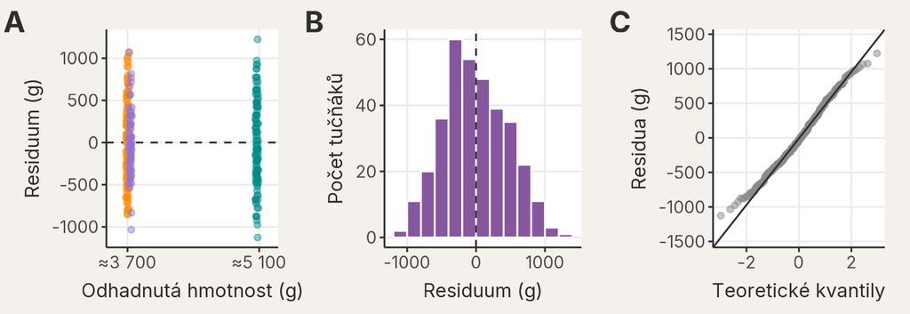

Vidíme systematický vzorec, odlehlé pozorování nebo výrazně odlišný rozptyl skupin?

Pásy Adélie a Chinstrap splývají, protože se jejich průměry liší jen o 32 g. Šířka pásů je podobná, histogram má jeden vrchol a Q–Q body sledují přímku.

## Nestojí výsledek na několika tučňácích?

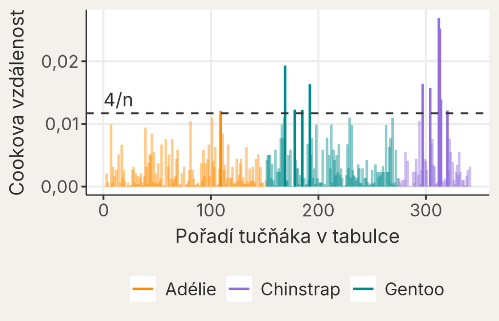

Zkuste si

Čáru 4/n přesahuje 11 z 342 tučňáků. Smažeme je?

Kontrola

Největší hodnota je jen 0,027. Bez jediného tučňáka se žádný koeficient nezmění o více než 16 g.

Vlivné tučňáky si prohlédneme, ale nemažeme je jen proto, že překročili hranici.

# Jedna otázka pro tři druhy

## Jedna otázka zůstala otevřená

Liší se průměrná hmotnost mezi druhy tučňáků?

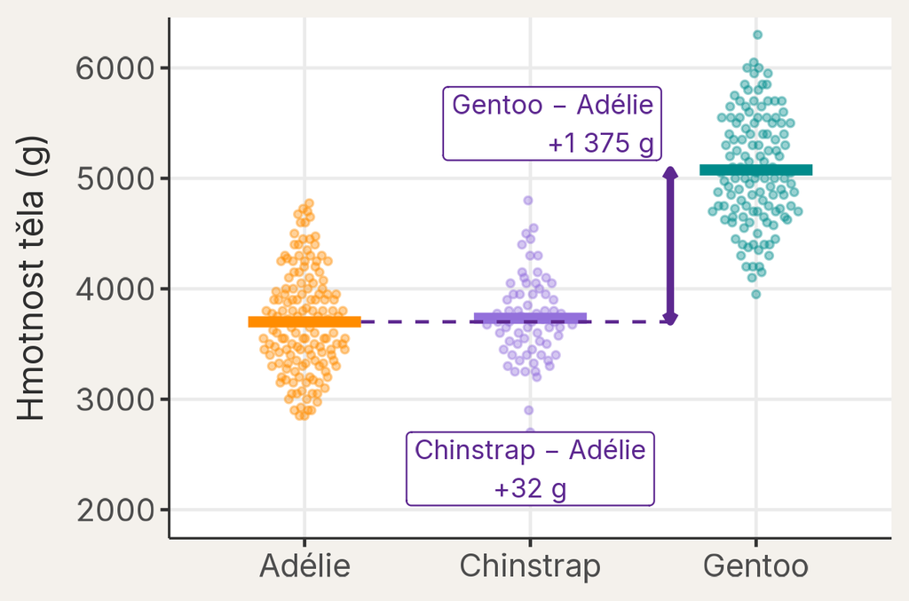

Co už víme

Dva rozdíly vůči Adélie. Každý má svůj řádek ve výstupu modelu.

Co zatím nevíme

Stačil by všem tučňákům jeden společný průměr, nebo potřebujeme tři?

Potřebujeme jednu otázku pro všechny tři druhy najednou, ne dva řádky zvlášť.

## Jeden nebo tři?

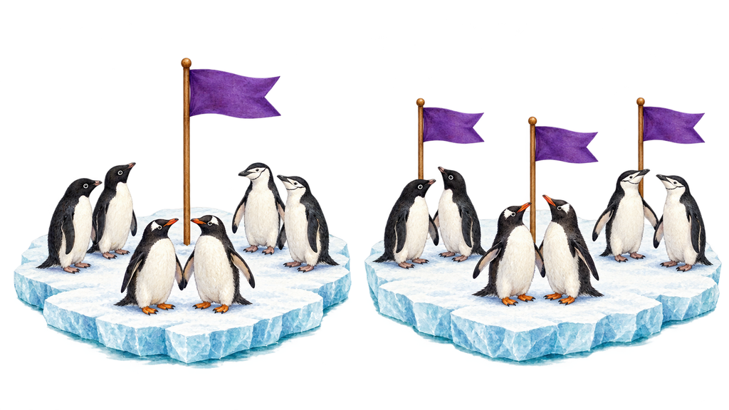

Ilustrace vytvořená pomocí AI.

**nulový model**: jeden společný průměr

**skupinový model**: jeden průměr pro každý druh

Tip

Ve kterém modelu budou vzdálenosti tučňáků od průměru (residua) kratší? Stačí jakékoli zkrácení, nebo musí být velké?

## Rozdíly průměrů proti variabilitě uvnitř skupin

Testová statistika porovnává **variabilitu (rozdíl) mezi skupinovými průměry** s **variabilitou jedinců uvnitř skupin**.

$$\frac{\text{variabilita (rozdíl) mezi skupinovými průměry}}{\text{variabilita jedinců uvnitř skupin}}$$

Čitatel roste, když se vzdalují průměry. Jmenovatel roste, když se více rozptylují jedinci.

## Součty čtverců ve třech skupinách

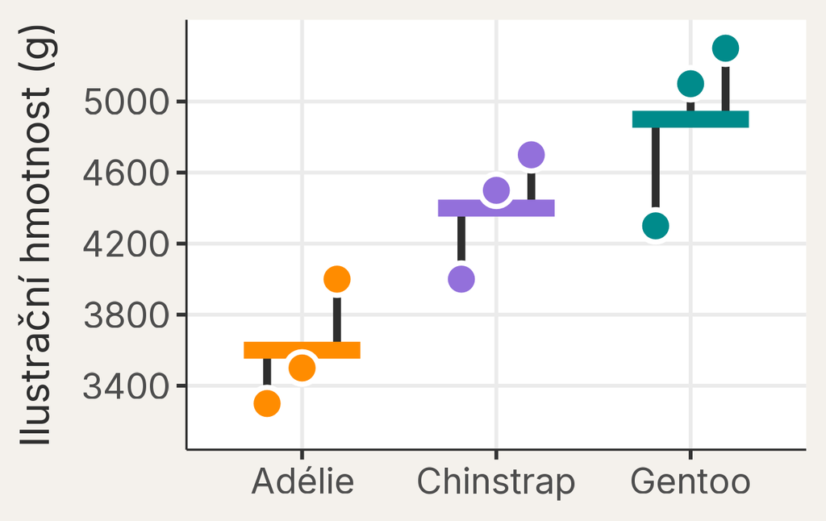

Malý vymyšlený příklad: tři tučňáci na druh.

1 minuta se sousedem

Jak byste z tohoto grafu spočítali součet čtverců uvnitř skupin? Popište postup slovy.

Součet čtverců uvnitř skupin = součet čtverců vzdáleností jedinců od průměru jejich druhu.

$$\begin{aligned}
\mathrm{SS}_{\text{Adélie}} &= (-300)^2 + (-100)^2 + (400)^2 = 260\,000 \\
\mathrm{SS}_{\text{Chinstrap}} &= (-400)^2 + (100)^2 + (300)^2 = 260\,000 \\
\mathrm{SS}_{\text{Gentoo}} &= (-600)^2 + (200)^2 + (400)^2 = 560\,000 \\
\mathrm{SS}_{\text{uvnitř}} &= 260\,000 + 260\,000 + 560\,000 \\
&= 1\,080\,000\ \mathrm{g}^2
\end{aligned}$$

## Skupinové průměry měří rozdíl mezi skupinami

$$\begin{aligned}
\text{součet čtverců mezi skupinami}
&= \text{velikosti skupin} \times \text{čtverce vzdáleností} \\
&\quad \text{skupinových průměrů od společného průměru}
\end{aligned}$$

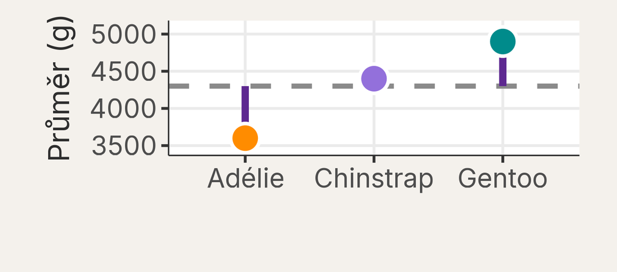

$$3 \times (-700)^2
+ 3 \times (100)^2
+ 3 \times (600)^2
= 2\,580\,000\ \mathrm{g}^2$$

Je to totéž číslo jako pokles součtu čtverců residuí po přidání skupinových průměrů.

## Celkový součet má dvě viditelné části

$$\begin{aligned}
\text{celkový součet čtverců}
&= \text{součet čtverců mezi skupinami} \\
&\quad + \text{součet čtverců uvnitř skupin (RSS)}
\end{aligned}$$

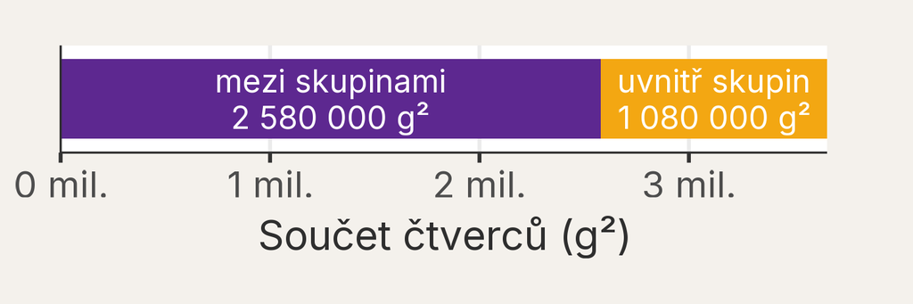

Celkový součet čtverců je RSS modelu s jedním průměrem; součet uvnitř skupin je RSS modelu se třemi průměry.

Tři průměry residua zkrátí vždy. Nestačí jakékoli zkrácení: musí být velké vzhledem k tomu, co zůstává uvnitř skupin.

## Dělením stupni volnosti získáme průměrné čtverce

$$\text{průměrný čtverec }(MS)
=
\frac{\text{součet čtverců }(SS)}{\text{stupně volnosti}}$$

Mezi skupinami

Tři průměry = jeden referenční + **dva rozdíly**

$$df = 3 - 1 = 2$$

$$MS_{\mathrm{mezi}}
=
\frac{2\,580\,000}{2}
=
1\,290\,000\ \mathrm{g}^2$$

Uvnitř skupin

9 tučňáků mínus 3 odhadnuté průměry

$$df = 9 - 3 = 6$$

$$MS_{\mathrm{uvnitř}}
=
\frac{1\,080\,000}{6}
=
180\,000\ \mathrm{g}^2$$

Oba součty čtverců přepočítáme na variabilitu připadající na jeden stupeň volnosti.

## Poměr průměrných čtverců je $F$

$$F
=
\frac{MS_{\mathrm{mezi}}}{MS_{\mathrm{uvnitř}}}
=
\frac{1\,290\,000}{180\,000}
=
\text{7,17}$$

$MS_{\mathrm{mezi}}$

variabilita připadající na jeden stupeň volnosti mezi skupinami

$MS_{\mathrm{uvnitř}}$

variabilita připadající na jeden stupeň volnosti uvnitř skupin

## Analýza se jmenuje ANOVA

ANOVA = analýza rozptylu

Název zdůrazňuje mechanismus: rozdíly mezi průměry posuzujeme pomocí rozptylu uvnitř skupin.

Model je stále `lm()`. ANOVA je test tohoto modelu.

## Stejný vnitřní rozptyl, jiný rozdíl

Pořadí panelů

Seřaďte panely od nejslabšího po nejsilnější důkaz proti shodným průměrům.

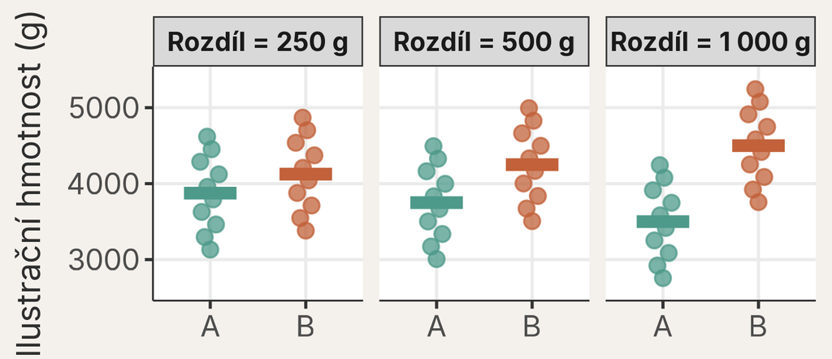

## Celková otázka v R

```r
# Celkový F-test pro mod_tri: jsou všechny tři průměry stejné?
anova(object = mod_tri)
```

```
Analysis of Variance Table

Response: hmotnost_tela_g
           Df    Sum Sq  Mean Sq F value    Pr(>F)
druh        2 146864214 73432107  343.63 < 2.2e-16 ***
Residuals 339  72443483   213698
---
Signif. codes:  0 '***' 0.001 '**' 0.01 '*' 0.05 '.' 0.1 ' ' 1
```

$F(2, 339) = \text{343,6}$, p-hodnota < 0,001: data jsou obtížně slučitelná se shodou všech tří průměrů.

## Kde leží naše $F$ v nulovém rozdělení?

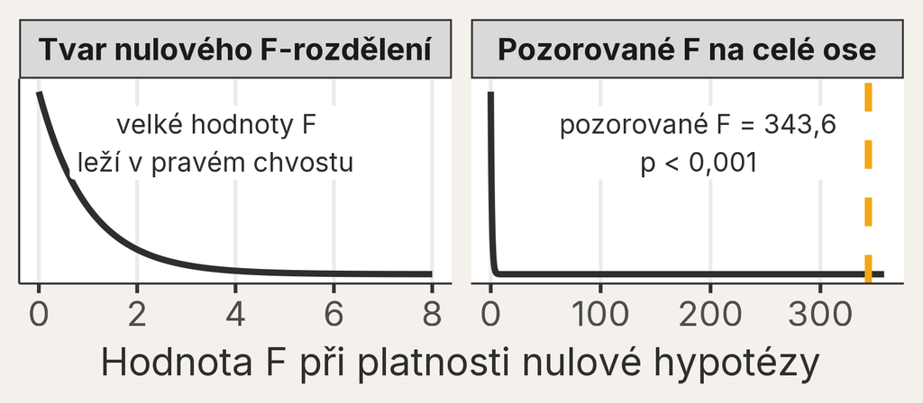

p-hodnota je plocha napravo od pozorovaného $F$; zde je tak malá, že ji v grafu téměř nevidíme.

## Co nám malá p-hodnota říká?

Hlasování

Který závěr plyne přímo z celkového F-testu?

A

Alespoň jeden průměr se liší.

B

Všechny dvojice se liší.

C

Gentoo je příčinou rozdílu.

Celkový test neříká, které konkrétní dvojice se liší.